# Walmart Sales Prediction Using Machine Learning - Rani Maklada

## Data

#### You have been provided with sales data (sales.csv) for 111 products whose sales may be affected by the weather. These 111 products are sold in stores at 45 different Walmart locations. Some of the products may be a similar item (such as milk) but have a different id in different stores/regions/suppliers. The 45 locations are covered by 20 weather stations (i.e., some of the stores are nearby and share a weather station). The key data (key.csv) indicates for each store to which weather station it belongs. In addition, you have been provided with the weather data (weather.csv) of each weather station. The sales and weather data are daily observations, from January 2012 to October 2014.

### A Data Exploration and Visualization

### B Data Pre-processing

### C Unit Sales Prediction

### D Rainy Day Prediction

### E Elevation Estimation

### F Clustering

# Section A (Data Exploration and Visualization)

```python
import pandas as pd
import numpy as np
import matplotlib.pyplot as plt
import seaborn as sns
from sklearn import preprocessing
from sklearn.neighbors import KNeighborsClassifier
from sklearn.model_selection import train_test_split, GridSearchCV,cross_val_score,KFold
from sklearn.preprocessing import StandardScaler
from sklearn.experimental import enable_iterative_imputer
from sklearn.impute import IterativeImputer
from sklearn.linear_model import LinearRegression
from sklearn.impute import KNNImputer
from sklearn.metrics import plot_confusion_matrix
# decision tree
from sklearn import tree
from sklearn.tree import DecisionTreeClassifier, DecisionTreeRegressor
# model evaluation
from sklearn.metrics import accuracy_score, mean_squared_error
# adaboost
from sklearn.ensemble import AdaBoostClassifier, AdaBoostRegressor
# gradient boosting
from sklearn.ensemble import GradientBoostingClassifier, GradientBoostingRegressor
# KNN
from sklearn.neighbors import KNeighborsClassifier, KNeighborsRegressor
# random forest
from sklearn.ensemble import RandomForestClassifier
RSEED = 10
```

```python
sales = pd.read_csv('sales.csv')
weather = pd.read_csv('weather.csv')
key = pd.read_csv('key.csv')
sns.set()
```

```python
sales.head(3)
```

|  | date | store_nbr | item_nbr | units |
| --- | --- | --- | --- | --- |
| 0 | 2012-01-01 | 1 | 1 | 0 |
| 1 | 2012-01-01 | 1 | 2 | 0 |
| 2 | 2012-01-01 | 1 | 3 | 0 |

```python
weather.head(3)
```

|  | station_nbr | date | tmax | tmin | tavg | depart | dewpoint | wetbulb | heat | cool | sunrise | sunset | codesum | snowfall | preciptotal | stnpressure | sealevel | resultspeed | resultdir | avgspeed |
| --- | --- | --- | --- | --- | --- | --- | --- | --- | --- | --- | --- | --- | --- | --- | --- | --- | --- | --- | --- | --- |
| 0 | 1 | 2012-01-01 | 52 | 31 | 42 | M | 36 | 40 | 23 | 0 | - | - | RA FZFG BR | M | 0.05 | 29.78 | 29.92 | 3.6 | 20 | 4.6 |
| 1 | 2 | 2012-01-01 | 48 | 33 | 41 | 16 | 37 | 39 | 24 | 0 | 0716 | 1626 | RA | 0.0 | 0.07 | 28.82 | 29.91 | 9.1 | 23 | 11.3 |
| 2 | 3 | 2012-01-01 | 55 | 34 | 45 | 9 | 24 | 36 | 20 | 0 | 0735 | 1720 |  | 0.0 | 0.00 | 29.77 | 30.47 | 9.9 | 31 | 10.0 |

```python
key.head(3)
```

|  | store_nbr | station_nbr |
| --- | --- | --- |
| 0 | 1 | 1 |
| 1 | 2 | 14 |
| 2 | 3 | 7 |

changing date from string to datetime type

```python
sales['date'] = pd.to_datetime(sales['date'], errors='coerce')
sales['month'] = sales['date'].dt.month
sales['dayofweek'] = sales['date'].dt.dayofweek
sales['dayofyear'] = sales['date'].dt.dayofyear
sales['year'] = sales['date'].dt.year
```

### Annual sales summary

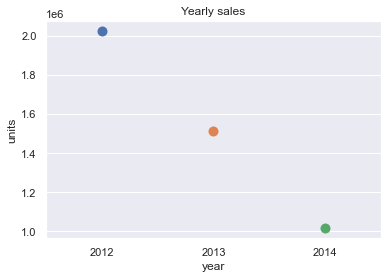

```python
sales_group = sales.groupby(['year']).sum()
sales_group.reset_index(inplace=True)
sns.swarmplot(x="year", y="units", data=sales_group, dodge=False, size=10).set(title='Yearly sales')
plt.show()
```

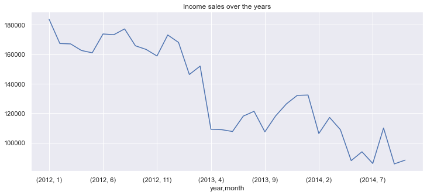

```python
months_in_year = ['-','January', 'February', 'March', 'April', 'May', 'June', 'July', 'August', 'September', 'October', 'November', 'December']
monthly_sale = sales.groupby(['year','month']).sum()
monthly_sale.reset_index(inplace=True)
monthly_sale.groupby(['year','month']).sum()['units'].plot(figsize=(12, 5),title="Income sales over the years");
```

You can learn from these graphs that there has been a decline in sales over the years

### Monthly sales summary

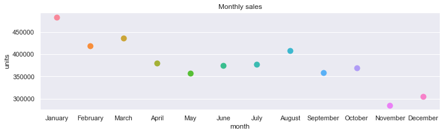

```python
plt.figure(figsize = (12,3))
sales_group = sales.groupby(['month']).sum()
sales_group.reset_index(inplace=True)
m=[]
for i in sales_group['month']:
    m.append(months_in_year[i])
sales_group['month'] = m
sns.swarmplot(x="month", y="units", data=sales_group, dodge=False, size=10).set(title='Monthly sales')
plt.show()
```

You can learn from the graph the ups and downs in sales during the year

### Comparison in Monthly sales over the years

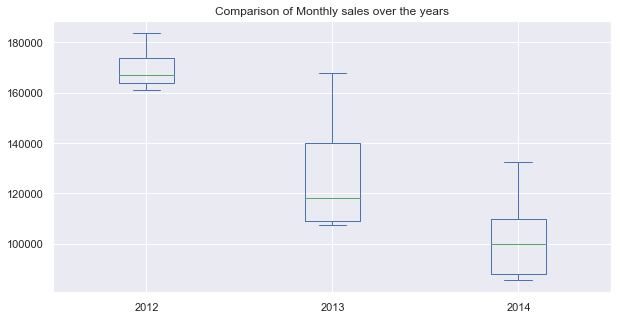

```python
sales_dum = sales.groupby(['month','year']).sum()
sales_dum['2012'] =  0
sales_dum['2013'] =  0
sales_dum['2014'] =  0
for i in sales_dum.index:
    sales_dum[str(i[1])].loc[i] = sales_dum['units'].loc[i]
sales_dum.reset_index(inplace=True)
sales_dum = sales_dum.groupby(['month']).sum()
sales_dum.reset_index(inplace=True)
m=[]
for i in sales_dum['month']:
    m.append(months_in_year[i])
sales_dum['month'] = m
sales_dum = sales_dum.set_index('month')
sales_dum.drop(index=['November','December'])[['2012','2013','2014']].plot.box(figsize=(10, 5),title="Comparison of Monthly sales over the years");
```

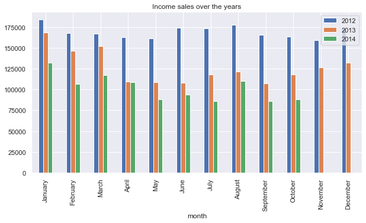

```python
sales_dum[['2012','2013','2014']].plot.bar(figsize=(10, 5),title="Income sales over the years");
```

### Weekly sales

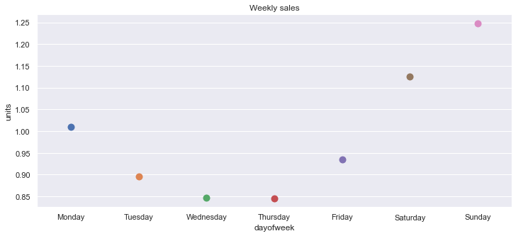

```python
days_in_week = ['Monday', 'Tuesday', 'Wednesday', 'Thursday', 'Friday', 'Saturday','Sunday']
sales_group = sales.groupby(['dayofweek']).mean()
sales_group.reset_index(inplace=True)
dw=[]
for i in sales_group['dayofweek']:
    dw.append(days_in_week[i])
sales_group['dayofweek'] = dw
plt.figure(figsize = (12,5))
sns.swarmplot(x="dayofweek", y="units", data=sales_group, dodge=False, size=10).set(title='Weekly sales')
plt.show()
```

You can learn from the graph the ups and downs in sales during the week.  
From the graph it can be seen that on the weekend there is an increase in sales compared to the mid-week.

### Top 10 selling days over the years

```python
sales_group = sales.groupby(['date']).sum()
sales_group.reset_index(inplace=True)
top_daily_sales = sales_group.sort_values(by=['units'], ascending=False).head(n=10)
worse_daily_sales = sales_group.sort_values(by=['units'], ascending=False).tail(n=10)
top_daily_sales['date'] = top_daily_sales['date'].astype('string')
worse_daily_sales['date'] = worse_daily_sales['date'].astype('string')
```

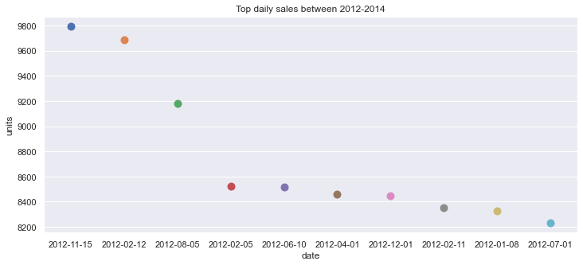

```python
plt.figure(figsize = (12,5))
sns.swarmplot(x="date", y="units", data=top_daily_sales, dodge=False, size=10).set(title='Top daily sales between 2012-2014')
plt.show()
```

### Distribution of stores between stations

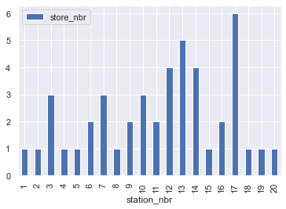

```python
groups = key.groupby(["station_nbr"]).count()
groups.plot.bar()
plt.show()
```

Match each store to the station by key.csv

```python
station = []
for i in sales['store_nbr']:
    station.append(key.loc[i-1,'station_nbr'])
sales['station_nbr'] = station
```

Sales distribution between stations

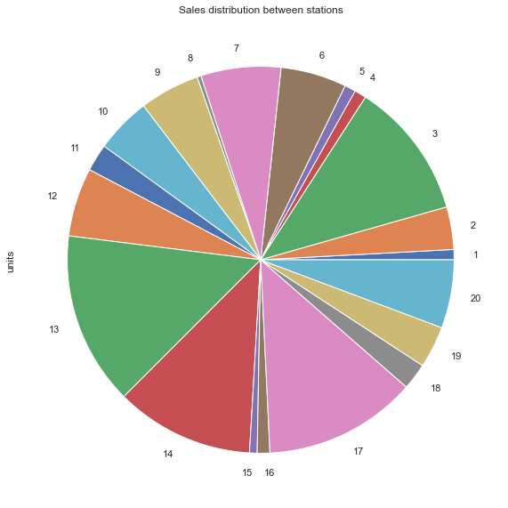

```python
station_sum = sales.groupby(['year','station_nbr'])['units'].sum()
sum_sales_years = sales.groupby(['year'])['units'].sum()
for i in station_sum.index:
    station_sum.loc[i] = (station_sum.loc[i]/sum_sales_years.loc[i[0]])
station_sum = station_sum.to_frame()
station_sum.reset_index(inplace=True)
station_sum = station_sum.groupby(['station_nbr']).mean()
station_sum['units'].plot.pie(figsize=(10, 10),title='Sales distribution between stations');
```

# Section B (Data Pre-processing)

In the data, we have a 'T' value that indicates a value close to zero.  
we decided to change it to 0.005

```python
weather['preciptotal'] = weather['preciptotal'].replace(['T', ' T', '  T'],0.005)
weather['snowfall'] = weather['snowfall'].replace(['T', ' T', '  T'],0.005)
weather['date'] = pd.to_datetime(weather['date'])
```

In the data, we have an 'M' value that indicates a missing value.  
we decided to change it to NaN value.  
Also, we decided to replace the empty value in 'codesum' culomn to MODERATE.  
Easier to handle.

```python
nan_value = float("NaN")
weather['codesum'].replace(" ", "MODERATE", inplace=True)
weather.replace("M", nan_value, inplace=True)
weather.replace(" M", nan_value, inplace=True)
weather.replace("-", nan_value, inplace=True)
weather.replace(" -", nan_value, inplace=True)
```

Calculate the percent of missing value in each column.

```python
drops = round(weather.isnull().sum()/weather.shape[0]*100,2)
```

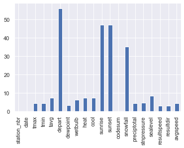

```python
drops.plot.bar()
```

If the percent is more than 45% we decided to drop the feature.  
Otherwise, we use the mice algorithm to calculate the missing value for features.

```python
(drops > 45)[(drops > 45) == True]
```

```
depart     True
sunrise    True
sunset     True
dtype: bool
```

```python
weather = weather.drop(columns=['depart', 'sunrise', 'sunset'])
```

```python
(drops < 45)[((drops < 45) == True) & ((drops > 0) == True)]
```

```
tmax           True
tmin           True
tavg           True
dewpoint       True
wetbulb        True
heat           True
cool           True
snowfall       True
preciptotal    True
stnpressure    True
sealevel       True
resultspeed    True
resultdir      True
avgspeed       True
dtype: bool
```

```python
columns = (drops < 45)[((drops < 45) == True) & ((drops > 0) == True)].index
weather_Mice = weather[columns]
lr = LinearRegression()
imp = IterativeImputer(estimator=lr,missing_values=np.nan, max_iter=10, verbose=2, imputation_order='roman',random_state=0)
weather_Mice = imp.fit_transform(weather_Mice)
weather_Mice = pd.DataFrame(weather_Mice)
weather[columns] = weather_Mice
```

```
[IterativeImputer] Completing matrix with shape (20517, 14)
[IterativeImputer] Ending imputation round 1/10, elapsed time 0.16
[IterativeImputer] Change: 61.581603484355874, scaled tolerance: 0.114
[IterativeImputer] Ending imputation round 2/10, elapsed time 0.29
[IterativeImputer] Change: 60.426148891449394, scaled tolerance: 0.114
[IterativeImputer] Ending imputation round 3/10, elapsed time 0.44
[IterativeImputer] Change: 14.402521133423072, scaled tolerance: 0.114
[IterativeImputer] Ending imputation round 4/10, elapsed time 0.57
[IterativeImputer] Change: 8.158955574035645, scaled tolerance: 0.114
[IterativeImputer] Ending imputation round 5/10, elapsed time 0.72
[IterativeImputer] Change: 7.16162109375, scaled tolerance: 0.114
[IterativeImputer] Ending imputation round 6/10, elapsed time 0.85
[IterativeImputer] Change: 6.317292213439941, scaled tolerance: 0.114
[IterativeImputer] Ending imputation round 7/10, elapsed time 0.99
[IterativeImputer] Change: 5.62123966217041, scaled tolerance: 0.114
[IterativeImputer] Ending imputation round 8/10, elapsed time 1.13
[IterativeImputer] Change: 5.1057886481285095, scaled tolerance: 0.114
[IterativeImputer] Ending imputation round 9/10, elapsed time 1.26
[IterativeImputer] Change: 4.722751617431641, scaled tolerance: 0.114
[IterativeImputer] Ending imputation round 10/10, elapsed time 1.39
[IterativeImputer] Change: 4.356130599975586, scaled tolerance: 0.114
```

Match each store to the station by key.csv

```python
station = []
for i in sales['store_nbr']:
    station.append(key.loc[i-1,'station_nbr'])
sales['station_nbr'] = station
```

The values in codesum column are categorical,  
so we use hot-encoding.

```python
weather = pd.concat([weather, weather['codesum'].str.get_dummies(sep=' ')], axis=1)
```

```python
weather = weather.drop(columns=['codesum'])
```

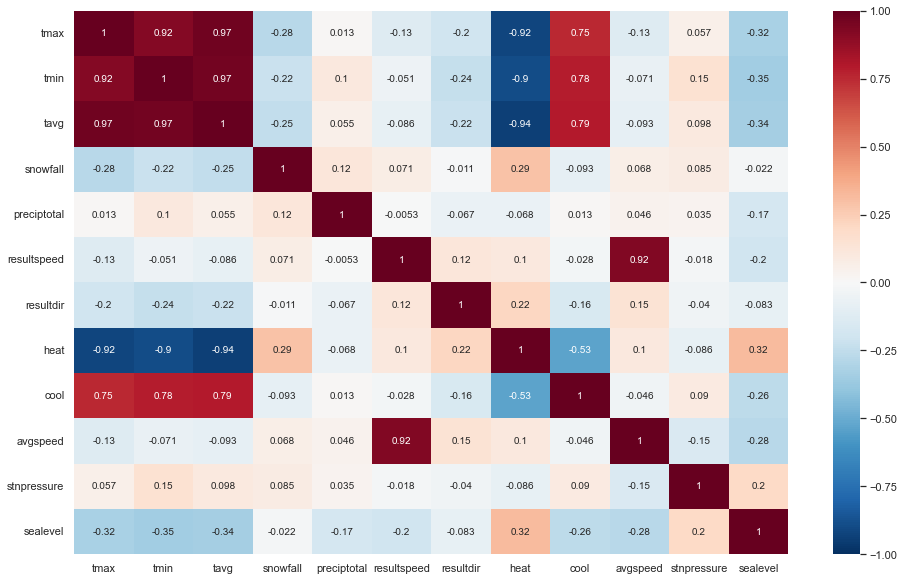

```python
weather_corr = weather[['tmax','tmin','tavg','snowfall','preciptotal','resultspeed','resultdir','heat','cool','avgspeed','stnpressure','sealevel']].corr()
plt.figure(figsize = (16,10))

sns.heatmap(data=weather_corr, cmap= 'RdBu_r', vmin=-1, vmax=1, annot=True, annot_kws={"size":10})
plt.show()
```

```python
weather = weather.drop(columns=['tmax','tmin','heat','resultspeed'])
```

# Section C (Unit Sales Prediction)

For this section we need only items [5,6,9,16,45].  
- We drop all the other items from the data.  
- We use groupby to Sum the values of the items for each store on a specific date.  
- The sum value is our key_sum.

```python
unit_sales = sales.loc[(sales['item_nbr'] == 5) | (sales['item_nbr'] == 6)
          | (sales['item_nbr'] == 9) | (sales['item_nbr'] == 16) | (sales['item_nbr'] == 45)]
```

```python
sunits_sum = unit_sales.groupby(['date','store_nbr'])['units'].sum()
unit_sales = unit_sales.groupby(['date','store_nbr']).mean()
unit_sales['units'] = sunits_sum
```

We can't use features that beeen used to create key_sum.  
So, we drop 'store_nbr' and 'item_nbr'.

```python
unit_sales.reset_index(inplace=True)
unit_sales = unit_sales.drop(columns=['item_nbr','store_nbr'])
```

```python
unit_sales.rename(columns = {'units':'key_sum'}, inplace = True)
```

We fit each store for the relevant station.

```python
unit_sales['station_nbr'] = unit_sales['station_nbr'].astype('int')
```

```python
weather_index = weather.set_index(['station_nbr','date'])
```

We merge the sales data and the weather data

```python
temp = weather_index[0:0]
for ind in unit_sales.index:
    temp = temp.append(weather_index.loc[(unit_sales['station_nbr'][ind],unit_sales['date'][ind])])
```

```python
temp.reset_index(inplace=True)
temp = temp.drop(columns=['date','station_nbr'])
```

```python
unit_sales = pd.get_dummies(unit_sales,columns=['station_nbr'])
```

```python
unit_sales['month'] = unit_sales['month'].astype('int')
unit_sales['dayofweek'] = unit_sales['dayofweek'].astype('int')
dw=[]
for i in unit_sales['dayofweek']:
    dw.append(days_in_week[i])
unit_sales['dayofweek'] = dw
```

```python
result = pd.concat([unit_sales, temp], axis=1, join='inner')
result = pd.get_dummies(result,columns=['month','dayofweek'])
```

```python
result.head(3)
```

|  | date | key_sum | dayofyear | year | station_nbr_1 | station_nbr_2 | station_nbr_3 | station_nbr_4 | station_nbr_5 | station_nbr_6 | ... | month_10 | month_11 | month_12 | dayofweek_Friday | dayofweek_Monday | dayofweek_Saturday | dayofweek_Sunday | dayofweek_Thursday | dayofweek_Tuesday | dayofweek_Wednesday |
| --- | --- | --- | --- | --- | --- | --- | --- | --- | --- | --- | --- | --- | --- | --- | --- | --- | --- | --- | --- | --- | --- |
| 0 | 2012-01-01 | 29 | 1.0 | 2012.0 | 1 | 0 | 0 | 0 | 0 | 0 | ... | 0 | 0 | 0 | 0 | 0 | 0 | 1 | 0 | 0 | 0 |
| 1 | 2012-01-01 | 191 | 1.0 | 2012.0 | 0 | 0 | 0 | 0 | 0 | 0 | ... | 0 | 0 | 0 | 0 | 0 | 0 | 1 | 0 | 0 | 0 |
| 2 | 2012-01-01 | 326 | 1.0 | 2012.0 | 0 | 0 | 0 | 0 | 0 | 0 | ... | 0 | 0 | 0 | 0 | 0 | 0 | 1 | 0 | 0 | 0 |

3 rows × 82 columns

```python
listof = result.columns.tolist()
```

```python
listof.remove('key_sum')
listof.remove('date')
listof.remove('year')
```

```python
mask = (result['year'] == 2012) | (result['year'] == 2013)
Xy_reg = result.loc[mask]
X_reg_train = Xy_reg[listof]
y_reg_train = Xy_reg['key_sum']

mask = (result['year'] == 2014)
Xy_reg = result.loc[mask]
X_reg_test = Xy_reg[listof]
y_reg_test = Xy_reg['key_sum']
```

### DecisionTreeRegressor

```python
# define model
dt = DecisionTreeRegressor(random_state=RSEED)

# define parameter grid
parameters_grid = {
    'max_depth': [2, 3, 4],
    'min_samples_split': [2, 3, 4],
    'min_samples_leaf': [2, 4, 8]
}

# define grid search
grid_search = GridSearchCV(estimator=dt, param_grid=parameters_grid, cv=10)

# fit estimator
grid_search.fit(X_reg_train, y_reg_train)

# get best estimator
best = grid_search.best_estimator_
```

```python
# predict
y_pred = best.predict(X_reg_test)
```

```python
# calculate MSE
MSE = round(mean_squared_error(y_reg_test, y_pred), 3)

df = pd.DataFrame([MSE]).T
df = df.rename(index={0: 'Decision Tree Regressor'}, columns={0: 'MSE'})
df
```

|  | MSE |
| --- | --- |
| Decision Tree Regressor | 2065.791 |

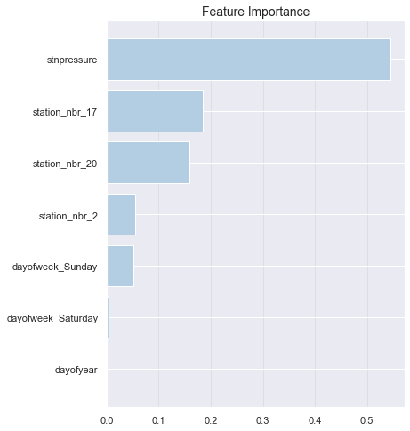

```python
# get feature importance
imp = pd.DataFrame(grid_search.best_estimator_.fit(X_reg_train, y_reg_train).feature_importances_,
                   index=X_reg_train.columns, columns=['Importance']).sort_values('Importance')
imp = imp[imp['Importance'] > 0]
# plot feature importance
plt.figure(figsize=(6, 8))
plt.barh(range(0, len(imp)), imp['Importance'], color='#b3cde3')
plt.grid(axis='x', alpha=0.5, color='lightgrey')
plt.yticks(range(0, len(imp)), imp.index)
plt.title('Feature Importance', fontsize=14)
plt.show()
```

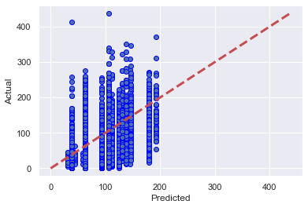

```python
fig, ax = plt.subplots()
ax.scatter(y_pred, y_reg_test, edgecolors=(0, 0, 1))
ax.plot([y_reg_test.min(), y_reg_test.max()], [y_reg_test.min(), y_reg_test.max()], 'r--', lw=3)
ax.set_xlabel('Predicted')
ax.set_ylabel('Actual')
plt.show()
```

### GradientBoostingRegressor

```python
# define model
gb = GradientBoostingRegressor(random_state=RSEED)

# define parameter grid
parameters_grid = {
    'learning_rate': [0.5, 1, 1.5],
    'n_estimators': [5, 15, 20]
}

# define grid search
grid_search = GridSearchCV(estimator=gb, param_grid=parameters_grid, cv=10)
```

```python
# fit estimator
grid_search.fit(X_reg_train, y_reg_train)

# get best estimator
best = grid_search.best_estimator_

# print best parameters
pd.DataFrame.from_dict(grid_search.best_params_, orient='index', columns=['Selected Value']).T
```

|  | learning_rate | n_estimators |
| --- | --- | --- |
| Selected Value | 0.5 | 15.0 |

```python
# predict
y_pred = best.predict(X_reg_test)

# calculate MSE
MSE = round(mean_squared_error(y_reg_test, y_pred), 3)

df = pd.DataFrame([MSE]).T
df = df.rename(index={0: 'Gradient Boosting Regressor'}, columns={0: 'MSE'})
df
```

|  | MSE |
| --- | --- |
| Gradient Boosting Regressor | 1732.861 |

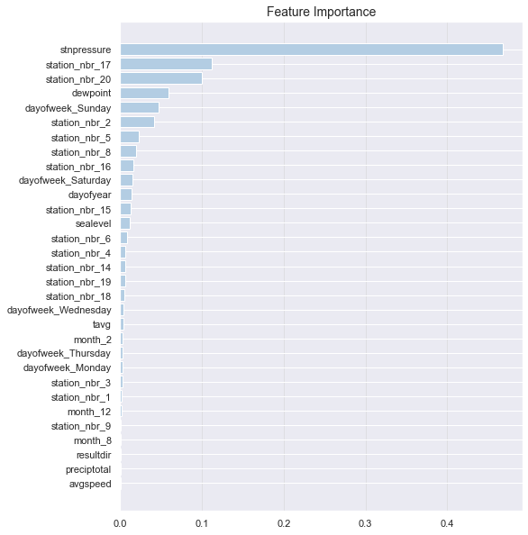

```python
# get feature importance
imp = pd.DataFrame(grid_search.best_estimator_.fit(X_reg_train, y_reg_train).feature_importances_,
                   index=X_reg_train.columns, columns=['Importance']).sort_values('Importance')
imp = imp[imp['Importance'] > 0]
# plot feature importance
plt.figure(figsize=(8, 10))
plt.barh(range(0, len(imp)), imp['Importance'], color='#b3cde3')
plt.grid(axis='x', alpha=0.5, color='lightgrey')
plt.yticks(range(0, len(imp)), imp.index)
plt.title('Feature Importance', fontsize=14)
plt.show()
```

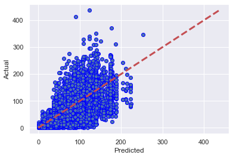

```python
fig, ax = plt.subplots()
ax.scatter(y_pred, y_reg_test, edgecolors=(0, 0, 1))
ax.plot([y_reg_test.min(), y_reg_test.max()], [y_reg_test.min(), y_reg_test.max()], 'r--', lw=3)
ax.set_xlabel('Predicted')
ax.set_ylabel('Actual')
plt.show()
```

### KNeighborsRegressor

```python
# define model
knn = KNeighborsRegressor()

# define parameter grid
parameters_grid = {
    'n_neighbors': [5, 10, 15, 25, 50],
    'weights': ['uniform', 'distance']
}

# define grid search
grid_search = GridSearchCV(estimator=knn, param_grid=parameters_grid, cv=10)

# fit estimator
grid_search.fit(X_reg_train, y_reg_train)

# get best estimator
best = grid_search.best_estimator_

# print best parameters
pd.DataFrame.from_dict(grid_search.best_params_, orient='index', columns=['Selected Value']).T
```

|  | n_neighbors | weights |
| --- | --- | --- |
| Selected Value | 50 | distance |

```python
# predict
y_pred = best.predict(X_reg_test)

# calculate MSE
MSE = round(mean_squared_error(y_reg_test, y_pred), 3)

df = pd.DataFrame([MSE]).T
df = df.rename(index={0: 'KNN Regressor'}, columns={0: 'MSE'})
df
```

|  | MSE |
| --- | --- |
| KNN Regressor | 2534.56 |

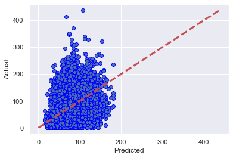

```python
fig, ax = plt.subplots()
ax.scatter(y_pred, y_reg_test, edgecolors=(0, 0, 1))
ax.plot([y_reg_test.min(), y_reg_test.max()], [y_reg_test.min(), y_reg_test.max()], 'r--', lw=3)
ax.set_xlabel('Predicted')
ax.set_ylabel('Actual')
plt.show()
```

# Section D (Rainy Day Prediction)

```python
Rainy_Day = sales.loc[(sales['store_nbr'] == 11)]
```

```python
Rainy_Day = Rainy_Day.drop(columns = 'store_nbr')
```

```python
rd = pd.get_dummies(Rainy_Day,columns=['item_nbr'])
for index, row in rd.iterrows():
    for i in rd.columns:
        if row[i] == 1:
            if 'item_nbr' in i:
                rd.loc[index,i] = row['units']
                break
```

```python
rd.head(3)
```

|  | date | units | month | dayofweek | dayofyear | year | station_nbr | item_nbr_1 | item_nbr_2 | item_nbr_3 | ... | item_nbr_102 | item_nbr_103 | item_nbr_104 | item_nbr_105 | item_nbr_106 | item_nbr_107 | item_nbr_108 | item_nbr_109 | item_nbr_110 | item_nbr_111 |
| --- | --- | --- | --- | --- | --- | --- | --- | --- | --- | --- | --- | --- | --- | --- | --- | --- | --- | --- | --- | --- | --- |
| 1110 | 2012-01-01 | 0 | 1 | 6 | 1 | 2012 | 10 | 0 | 0 | 0 | ... | 0 | 0 | 0 | 0 | 0 | 0 | 0 | 0 | 0 | 0 |
| 1111 | 2012-01-01 | 0 | 1 | 6 | 1 | 2012 | 10 | 0 | 0 | 0 | ... | 0 | 0 | 0 | 0 | 0 | 0 | 0 | 0 | 0 | 0 |
| 1112 | 2012-01-01 | 0 | 1 | 6 | 1 | 2012 | 10 | 0 | 0 | 0 | ... | 0 | 0 | 0 | 0 | 0 | 0 | 0 | 0 | 0 | 0 |

3 rows × 118 columns

```python
rd1 = rd[['date','units','month','dayofweek','dayofyear','year','station_nbr']]
rd2 = rd.groupby(['date']).sum()
# rd2.reset_index(inplace=True)
columns_drop = rd1.columns.tolist()
columns_drop.remove('date')
rd2 = rd2.drop(columns=columns_drop)
rd1 = rd1.groupby(['date']).mean()
```

```python
rd = pd.concat([rd1, rd2], axis=1, join='inner')
```

```python
rd.rename(columns = {'units':'avg_units'}, inplace = True)
```

```python
preciptotal_index = weather_index['preciptotal']
```

```python
key[key['store_nbr'] == 11]
```

|  | store_nbr | station_nbr |
| --- | --- | --- |
| 10 | 11 | 10 |

```python
for ind in rd.index:
    row = weather_index.loc[(10, ind)]
    for column in row.index:
        rd.loc[ind,column] = row[column]
```

```python
rd['month'] = rd['month'].astype('int')
rd['dayofweek'] = rd['dayofweek'].astype('int')
dw=[]
for i in rd['dayofweek']:
    dw.append(days_in_week[i])
rd['dayofweek'] = dw
rd = pd.get_dummies(rd,columns=['month','dayofweek'])
```

```python
rd.head(3)
```

| date | avg_units | dayofyear | year | station_nbr | item_nbr_1 | item_nbr_2 | item_nbr_3 | item_nbr_4 | item_nbr_5 | item_nbr_6 | ... | month_10 | month_11 | month_12 | dayofweek_Friday | dayofweek_Monday | dayofweek_Saturday | dayofweek_Sunday | dayofweek_Thursday | dayofweek_Tuesday | dayofweek_Wednesday |
| --- | --- | --- | --- | --- | --- | --- | --- | --- | --- | --- | --- | --- | --- | --- | --- | --- | --- | --- | --- | --- | --- |
| 2012-01-01 | 1.099099 | 1.0 | 2012.0 | 10.0 | 0 | 0 | 0 | 0 | 0 | 0 | ... | 0 | 0 | 0 | 0 | 0 | 0 | 1 | 0 | 0 | 0 |
| 2012-01-02 | 1.081081 | 2.0 | 2012.0 | 10.0 | 0 | 0 | 0 | 0 | 0 | 0 | ... | 0 | 0 | 0 | 0 | 1 | 0 | 0 | 0 | 0 | 0 |
| 2012-01-03 | 0.846847 | 3.0 | 2012.0 | 10.0 | 0 | 0 | 0 | 0 | 0 | 0 | ... | 0 | 0 | 0 | 0 | 0 | 0 | 0 | 0 | 1 | 0 |

3 rows × 173 columns

```python
mask = (rd['year'] == 2012) | (rd['year'] == 2013)
Xy_cls = rd.loc[mask]
X_cls_train = Xy_cls[Xy_cls.columns]
X_cls_train = X_cls_train.drop(columns=['preciptotal','snowfall','RA','year','station_nbr'])
y_cls_train = Xy_cls['preciptotal']
y_cls_train = y_cls_train > 0

mask = (rd['year'] == 2014)
Xy_cls = rd.loc[mask]
X_cls_test = Xy_cls[rd.columns]
X_cls_test = X_cls_test.drop(columns=['preciptotal','snowfall','RA','year','station_nbr'])
y_cls_test = Xy_cls['preciptotal']
y_cls_test = y_cls_test > 0
```

```python
rd = rd.drop(columns=['year','station_nbr'])
```

```python
results = []
models = []
kfold = KFold()
```

### DecisionTreeClassifier

```python
# define model
dt = DecisionTreeClassifier(random_state=RSEED)

# define parameter grid
parameters_grid = {
    'max_depth': [2,4],
    'min_samples_split': [2,4,6,8],
    'min_samples_leaf': [2,4,8,10]
}

# define grid search
grid_search = GridSearchCV(estimator=dt, param_grid=parameters_grid, cv=10)

# fit estimator
grid_search.fit(X_cls_train, y_cls_train)

# get best estimator
best = grid_search.best_estimator_

# print best parameters
pd.DataFrame.from_dict(grid_search.best_params_, orient='index', columns=['Selected Value']).T
```

|  | max_depth | min_samples_leaf | min_samples_split |
| --- | --- | --- | --- |
| Selected Value | 2 | 2 | 2 |

```python
cv_results = cross_val_score(dt, X_cls_train, y_cls_train, cv=kfold, scoring='accuracy')
results.append(cv_results)
models.append('DecisionTree')
```

```python
# predict
y_pred = best.predict(X_cls_test)

# calculate accuracy
acc = round(accuracy_score(y_cls_test, y_pred), 3)
df = pd.DataFrame([acc]).T
df = df.rename(index={0: 'Decision Tree Classifier'}, columns={0: 'Accuracy'})
df
```

|  | Accuracy |
| --- | --- |
| Decision Tree Classifier | 0.855 |

[figure not shown]

```python
plt.figure(figsize=(15, 15))
tr = tree.plot_tree(best, feature_names=X_cls_train.columns, class_names=['True', 'False'], filled=True)
```

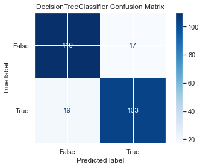

```python
# plot confusion metrics
plot_confusion_matrix(best, X_cls_test, y_cls_test, cmap='Blues')
plt.title("DecisionTreeClassifier Confusion Matrix")
plt.show()
```

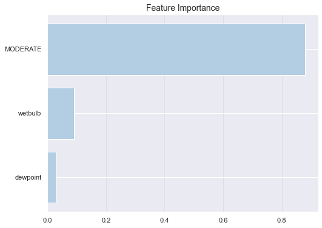

```python
# get feature importance
imp = pd.DataFrame(grid_search.best_estimator_.fit(X_cls_train, y_cls_train).feature_importances_,
                   index=X_cls_train.columns, columns=['Importance']).sort_values('Importance')
imp = imp[imp['Importance'] > 0]
# plot feature importance
plt.figure(figsize=(8, 6))
plt.barh(range(0, len(imp)), imp['Importance'], color='#b3cde3')
plt.grid(axis='x', alpha=0.5, color='lightgrey')
plt.yticks(range(0, len(imp)), imp.index)
plt.title('Feature Importance', fontsize=14)
plt.show()
```

### AdaBoostClassifier

```python
# define model
ab = AdaBoostClassifier(random_state=RSEED)

# define parameter grid
parameters_grid = {
    'n_estimators': [15,30]
}

# define grid search
grid_search = GridSearchCV(estimator=ab, param_grid=parameters_grid, cv=10)

# fit estimator
grid_search.fit(X_cls_train, y_cls_train)


# get best estimator
best = grid_search.best_estimator_

# print best parameters
pd.DataFrame.from_dict(grid_search.best_params_, orient='index', columns=['Selected Value']).T
```

|  | n_estimators |
| --- | --- |
| Selected Value | 15 |

```python
cv_results = cross_val_score(ab, X_cls_train, y_cls_train, cv=kfold, scoring='accuracy')
results.append(cv_results)
models.append('AdaBoost')
```

```python
# predict
y_pred = best.predict(X_cls_test)
```

```python
# calculate accuracy
acc = round(accuracy_score(y_cls_test, y_pred), 3)

df = pd.DataFrame([acc]).T
df = df.rename(index={0: 'AdaBoost Classifier'}, columns={0: 'Accuracy'})
df
```

|  | Accuracy |
| --- | --- |
| AdaBoost Classifier | 0.819 |

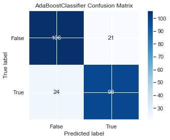

```python
# plot confusion metrics
plot_confusion_matrix(best, X_cls_test, y_cls_test, cmap='Blues')
plt.title("AdaBoostClassifier Confusion Matrix")
plt.show()
```

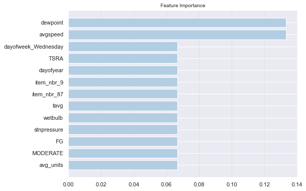

```python
# get feature importance
imp = pd.DataFrame(grid_search.best_estimator_.fit(X_cls_train, y_cls_train).feature_importances_,
                   index=X_cls_train.columns, columns=['Importance']).sort_values('Importance')
imp = imp[imp['Importance'] > 0]
# plot feature importance
plt.figure(figsize=(8, 6))
plt.barh(range(0, len(imp)), imp['Importance'], color='#b3cde3')
plt.grid(axis='x', alpha=0.5, color='lightgrey')
plt.yticks(range(0, len(imp)), imp.index)
plt.title('Feature Importance', fontsize=10)
plt.show()
```

### KNeighborsClassifier

```python
# define model
knn = KNeighborsClassifier()

# define parameter grid
parameters_grid = {
    'n_neighbors': [5, 10, 15],
    'weights': ['uniform', 'distance']
}

# define grid search
grid_search = GridSearchCV(estimator=knn, param_grid=parameters_grid, cv=10)

# fit estimator
grid_search.fit(X_cls_train, y_cls_train)

# get best estimator
best = grid_search.best_estimator_

# print best parameters
pd.DataFrame.from_dict(grid_search.best_params_, orient='index', columns=['Selected Value']).T
```

|  | n_neighbors | weights |
| --- | --- | --- |
| Selected Value | 10 | distance |

```python
cv_results = cross_val_score(knn, X_cls_train, y_cls_train, cv=kfold, scoring='accuracy')
results.append(cv_results)
models.append('KNeighbors')
```

```python
# predict
y_pred = best.predict(X_cls_test)

# calculate accuracy
acc = round(accuracy_score(y_cls_test, y_pred), 3)

df = pd.DataFrame([acc]).T
df = df.rename(index={0: 'KNN Classifier'}, columns={0: 'Accuracy'})
df
```

|  | Accuracy |
| --- | --- |
| KNN Classifier | 0.606 |

[figure not shown]

```python
# plot confusion metrics
plot_confusion_matrix(best, X_cls_test, y_cls_test, cmap='Blues')
plt.title("AdaBoostClassifier Confusion Matrix")
plt.show()
```

### RandomForestClassifier

```python
# define model
rf = RandomForestClassifier(random_state=RSEED)

# define parameter grid
parameters_grid = {
    'max_depth': [3, 4, 5],
    'min_samples_split': [2, 3, 4],
    'min_samples_leaf': [2, 4, 6],
    'n_estimators': [20, 50, 80]
}

# define grid search
grid_search = GridSearchCV(estimator=rf, param_grid=parameters_grid, cv=10)

# fit estimator
grid_search.fit(X_cls_train, y_cls_train)

# get best estimator
best = grid_search.best_estimator_

# print best parameters
pd.DataFrame.from_dict(grid_search.best_params_, orient='index', columns=['Selected Value']).T
```

|  | max_depth | min_samples_leaf | min_samples_split | n_estimators |
| --- | --- | --- | --- | --- |
| Selected Value | 4 | 6 | 2 | 20 |

```python
cv_results = cross_val_score(rf, X_cls_train, y_cls_train, cv=kfold, scoring='accuracy')
results.append(cv_results)
models.append('RandomForest')
```

```python
# model evaluation
from sklearn import metrics
from sklearn.metrics import accuracy_score
from sklearn.metrics import plot_confusion_matrix
```

```python
def get_metrics(y_test, y_pred):

    actual_pos = y_test == 1
    actual_neg = y_test == 0

    # get confusion matrix
    mat = metrics.confusion_matrix(y_test, y_pred)
    true_neg, false_pos, false_neg, true_pos = mat.ravel()

    # calculate sensitivity and specificity
    sensitivity = round(true_pos / np.sum(actual_pos), 3)
    specificity = round(true_neg / np.sum(actual_neg), 3)

    return sensitivity, specificity
```

```python
# predict
y_pred = best.predict(X_cls_test)

# calculate metrics
acc = round(accuracy_score(y_cls_test, y_pred), 3)
sensitivity, specificity = get_metrics(y_cls_test, y_pred)

# display metrics
rf_df = pd.DataFrame([acc, sensitivity, specificity]).T
rf_df = rf_df.rename(index={0: 'Random Forest Classifier'}, columns={0: 'Accuracy', 1: 'Sensitivity', 2: 'Specificity'})
rf_df
```

|  | Accuracy | Sensitivity | Specificity |
| --- | --- | --- | --- |
| Random Forest Classifier | 0.807 | 0.721 | 0.89 |

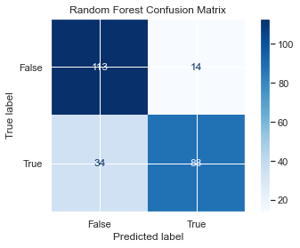

```python
# plot confusion metrics
plot_confusion_matrix(best, X_cls_test, y_cls_test, cmap='Blues')
plt.title("Random Forest Confusion Matrix")
plt.show()
```

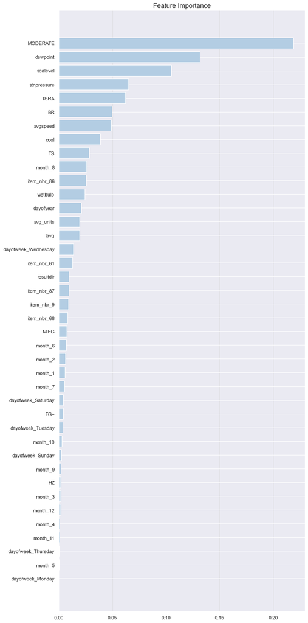

```python
# get feature importance
imp = pd.DataFrame(grid_search.best_estimator_.fit(X_cls_train, y_cls_train).feature_importances_,
                   index=X_cls_train.columns, columns=['Importance']).sort_values('Importance')
imp = imp[imp['Importance'] > 0]
# plot feature importance
plt.figure(figsize=(10, 25))
plt.barh(range(0, len(imp)), imp['Importance'], color='#b3cde3')
plt.grid(axis='x', alpha=0.5, color='lightgrey')
plt.yticks(range(0, len(imp)), imp.index)
plt.title('Feature Importance', fontsize=15)
plt.show()
```

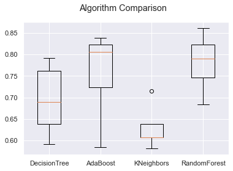

```python
# boxplot algorithm comparison
fig = plt.figure()
fig.suptitle('Algorithm Comparison')
ax = fig.add_subplot(111)
plt.boxplot(results)
ax.set_xticklabels(models)
plt.show()
```

# Section E (Elevation Estimation - Bonus)

```python
import math
```

```python
g = 9.80665
M = 0.0289644
R = 8.31432
```

```python
Estimate = weather[['station_nbr','tavg','stnpressure','sealevel']]
```

```python
Estimate = Estimate.groupby(['station_nbr']).mean()
```

$P={Po\;e^{\frac{-gM(h-ho)}{RT}\;}}$

```python
for i in Estimate.index:
    Estimate.loc[i,'Elevation'] = (np.log(Estimate.loc[i,'stnpressure']/Estimate.loc[i,'sealevel'])*R*(Estimate.loc[i,'tavg']+459.67)*5/9)/(-g*M)
```

```python
Estimate.head(3)
```

| station_nbr | tavg | stnpressure | sealevel | Elevation |
| --- | --- | --- | --- | --- |
| 1 | 52.355015 | 29.845781 | 30.013739 | 46.725881 |
| 2 | 50.142881 | 28.906484 | 30.009350 | 310.421292 |
| 3 | 62.651866 | 29.276713 | 29.997405 | 206.558637 |

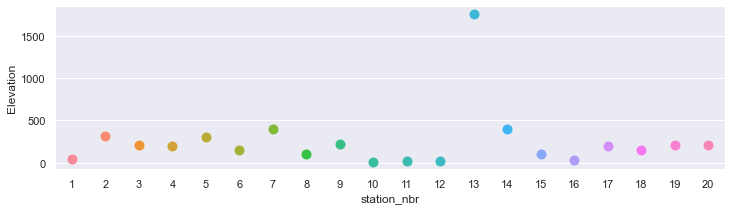

```python
plt.figure(figsize = (12,3))
Estimate.reset_index(inplace=True)
sns.swarmplot(x="station_nbr", y="Elevation", data=Estimate, dodge=False, size=10)
plt.show()
```